# hw4

# 5. Answer the following question using numerical and graphical summary: Which chick gained the most weight and which gained the least weight? What diets were they on?

Based on the following table and graph, chick 35 gained the most weight while chick 24 gained the least weight. Chick 35 was on diet 3 while chick 24 was on diet 2.

```r
csum <- complete %>% group_by(Chick, Diet) %>% summarize(tot_gain = max(weightgain)) %>% arrange(tot_gain)

print(tbl_df(csum), n = 50)
```

```
## # A tibble: 45 x 3
##    Chick Diet  tot_gain
##    <ord> <fct>    <dbl>
##  1 24    2           34
##  2 13    1           55
##  3 9     1           58
##  4 20    1           76
##  5 10    1           83
##  6 17    1          100
##  7 19    1          114
##  8 30    2          115
##  9 33    3          117
## 10 4     1          118
## 11 6     1          119
## 12 22    2          126
```

[output cut: 33 more lines]

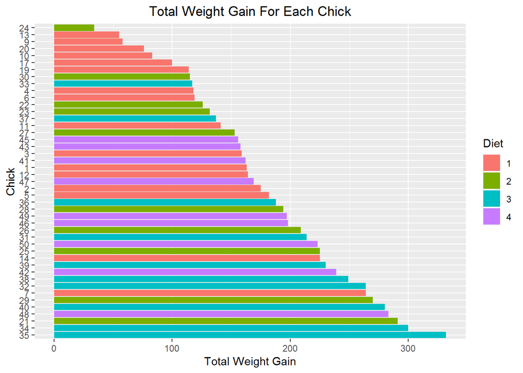

```r
ggplot(csum, aes(x = reorder(Chick, -tot_gain), y = tot_gain, fill = Diet)) + geom_bar(stat = "identity") + coord_flip() + labs(title = "Total Weight Gain For Each Chick", x = "Chick" , y = "Total Weight Gain") + theme(plot.title = element_text(hjust = 0.5))
```

# 6. For the chicks with the least and the most weight at time 0, plot their growth trajectories over time. 5 pts of extra credit: Add to the plot the average growth trajectory for all chicks (calculated as the mean weight for each chick at each time). How do the trajectories compare?

Chick 3 is gaining weight faster than chick 27.

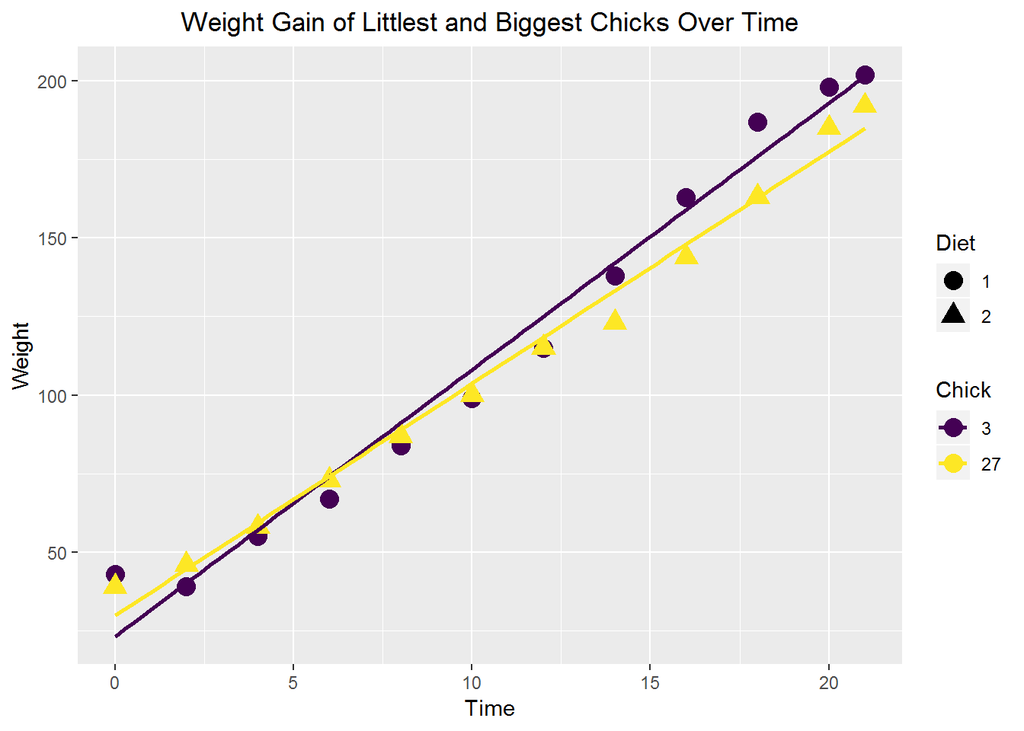

```r
stdate <- complete %>% filter(Time == 0) %>% arrange(weight)
littchick <- stdate$Chick[which.min(stdate$weight)]
biggchick <- stdate$Chick[which.max(stdate$weight)]
scattchick <- complete %>% filter(Chick == littchick | Chick == biggchick)

ggplot(scattchick, aes(x = Time, y = weight, shape = Diet, color = Chick)) + geom_point(size = 4) + geom_smooth(method = lm, se = FALSE, fullrange = TRUE) + labs(title = "Weight Gain of Littlest and Biggest Chicks Over Time", y = "Weight") + theme(plot.title = element_text(hjust = 0.5))
```

# 7. What else do you find interesting in the dataset? Show your exploratory analysis.

After looking back at the graphs from questions 4 and 5, I wanted to take a look at the distribution of plot points of all the chicks in each diet group based on weight gain over the span of time. While the distributions look very similar, the data spread varies a lot towards the end. Also it appears that Diet 2 and 4 have the widest and narrowest spread towards the end of the graphs.

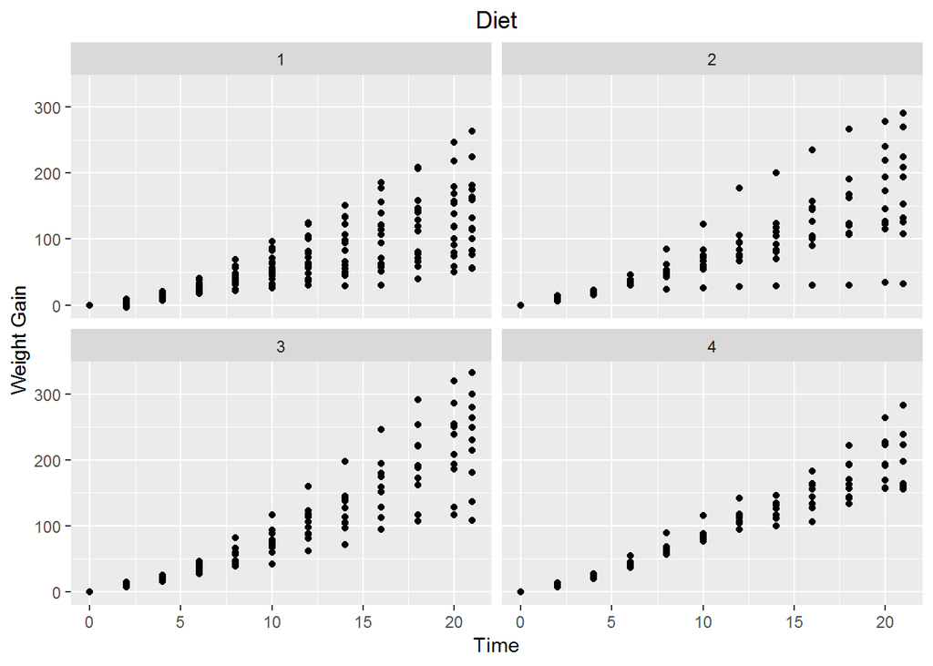

```r
ggplot(complete, aes(x = Time, y = weightgain)) + geom_point() + facet_wrap(~Diet) + labs(title = "Diet", y = "Weight Gain") + theme(plot.title = element_text(hjust = 0.5))
```